# 外國人來台灣數量及外配分析

yahsuanyeh

2017年6月20日

## 分析議題背景

組員姓名 B0344126鄭筠臻、B0344129葉亞萱 在地球村的時代，每年哪一國人最常來台灣呢，來台灣又有哪些目的呢? 想知道台灣的新住民與外國人來台目的的關係!

## 分析動機

台灣是觀光勝地，想了解那些世界各國來台灣，找出前10名，找出與台灣密切往來的國家，並了解其目的，分析目的主要原因為何?例如：業務、觀光、探親、會議、求學、展覽、醫療……等等。想透過大數據R語言解釋出台灣在世界各國的重要性。

## 使用資料

http://admin.taiwan.net.tw/statistics/year.aspx?no=134

載入使用資料們

```r
library(readr)
country<- read_csv("C:/Users/X550LD/Desktop/visitor arrivals (2003-2016).csv")
View(country)
country$X1<-
  iconv(country$X1,
        from="big5", to = "UTF-8")

library(readr)
purpose_2016 <- read_csv("C:/Users/X550LD/Desktop/visitor arrivals by purpose(2016) .csv")
View(purpose_2016)

purpose_2016$Residence<-
  iconv(purpose_2016$Residence,
        from="big5", to = "UTF-8")
```

## 資料處理與清洗

取出2016年，來台人數的資料，再把兩個表合起來，找出那些國家是前10名。

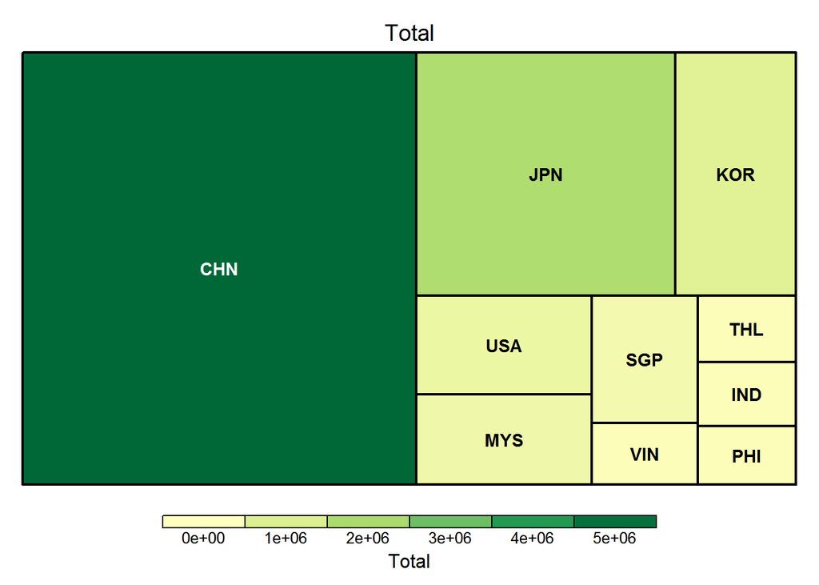

```r
library(readr)
countrycode <- read_csv("C:/Users/X550LD/Desktop/Code.csv")
View(countrycode)
countrycode$Residence<-
  iconv(countrycode$Residence,
        from="big5", to = "UTF-8")

library(dplyr)
purpose_2016_code<-inner_join(purpose_2016,countrycode, by = "Residence")

library(treemap)
data(purpose_2016_code)
treemap(purpose_2016_code,
       index=c("code"),
       vSize="Total",
       vColor="Total",
       type="value")
```

```r
library(knitr)
knitr::kable(
  purpose_2016_code[1:10,1:2])
```

[output not shown]

```r
country10<-head(country[order(country$X_2016,decreasing = T),],10)
country10<-subset(country10,select = c(X1,X_2016))
library(dplyr)
top10<-inner_join(country10,purpose_2016_code,c("X1"="Residence"))

library(knitr)
knitr::kable(
  top10[1:10,])
```

| X1 | X_2016 | Total | Business | Pleasure | VisitRelatives | Conference | Study | Exhibition | MedicalTreatment | Others | code |
| --- | --- | --- | --- | --- | --- | --- | --- | --- | --- | --- | --- |
| 中國大陸(含港澳) China | 4987259 | 5126537 | 102014 | 4242780 | 111667 | 8775 | 31104 | 269 | 33152 | 596776 | CHN |
| 日本 Japan | 1896456 | 1895702 | 253159 | 1379233 | 21403 | 10572 | 5707 | 1245 | 124 | 224259 | JPN |
| 韓國 Korea,Republic of | 887412 | 884397 | 59578 | 693224 | 17791 | 5727 | 6112 | 3125 | 81 | 98759 | KOR |
| 美國 United States of America | 542261 | 523888 | 97081 | 166044 | 148645 | 6434 | 3983 | 571 | 397 | 100733 | USA |
| 馬來西亞 Malaysia | 500496 | 474420 | 19269 | 339710 | 15475 | 4569 | 2211 | 1540 | 743 | 90903 | MYS |
| 新加坡 Singapore | 371663 | 407267 | 43378 | 292240 | 13931 | 4472 | 1839 | 964 | 189 | 50254 | SGP |
| 越南 Vietnam | 194323 | 196636 | 6916 | 36839 | 17098 | 1321 | 1317 | 318 | 195 | 132632 | VIN |
| 泰國 Thailand | 193200 | 195640 | 10179 | 110116 | 6652 | 2490 | 1367 | 866 | 94 | 63876 | THL |
| 印尼 Indonesia | 192053 | 188720 | 5201 | 32868 | 8626 | 2019 | 1752 | 738 | 530 | 136986 | IND |
| 菲律賓 Philippines | 171816 | 172475 | 6551 | 48198 | 4843 | 3238 | 591 | 527 | 255 | 108272 | PHI |

```r
top10$Total<-as.double(top10$Total)
top10$Business<-as.double(top10$Business)
top10$Pleasure<-as.double(top10$Pleasure)
top10$VisitRelatives<-as.double(top10$VisitRelatives)
top10$Conference<-as.double(top10$Conference)
top10$Study<-as.double(top10$Study)
top10$Exhibition<-as.double(top10$Exhibition)
top10$MedicalTreatment<-as.double(top10$MedicalTreatment)
top10$Others<-as.double(top10$Others)

top10$"Percentage of Business"<-top10$Business/top10$Total*100
top10$"Percentage of Pleasure"<-top10$Pleasure/top10$Total*100
top10$"Percentage of VisitRelatives"<-top10$VisitRelatives/top10$Total*100
top10$"Percentage of Conference"<-top10$Conference/top10$Total*100
top10$"Percentage of Study"<-top10$Study/top10$Total*100
top10$"Percentage of Exhibition"<-top10$Exhibition/top10$Total*100
top10$"Percentage of MedicalTreatment"<-top10$MedicalTreatment/top10$Total*100
top10$"Percentage of Others"<-top10$Others/top10$Total*100
top10$"Country"<-top10$'X1'

top10_purpose<-subset(top10,select =
                        c("code","Percentage of Business","Percentage of Pleasure","Percentage of VisitRelatives","Percentage of Conference","Percentage of Study","Percentage of Exhibition","Percentage of MedicalTreatment","Percentage of Others"))
library(knitr)
knitr::kable(
  top10_purpose[1:10,])
```

| code | Percentage of Business | Percentage of Pleasure | Percentage of VisitRelatives | Percentage of Conference | Percentage of Study | Percentage of Exhibition | Percentage of MedicalTreatment | Percentage of Others |
| --- | --- | --- | --- | --- | --- | --- | --- | --- |
| CHN | 1.989920 | 82.76113 | 2.178215 | 0.1711682 | 0.6067254 | 0.0052472 | 0.6466744 | 11.64092 |
| JPN | 13.354367 | 72.75579 | 1.129028 | 0.5576826 | 0.3010494 | 0.0656749 | 0.0065411 | 11.82987 |
| KOR | 6.736567 | 78.38380 | 2.011653 | 0.6475599 | 0.6910923 | 0.3533481 | 0.0091588 | 11.16682 |
| USA | 18.530869 | 31.69456 | 28.373431 | 1.2281251 | 0.7602770 | 0.1089928 | 0.0757796 | 19.22796 |
| MYS | 4.061591 | 71.60533 | 3.261878 | 0.9630707 | 0.4660427 | 0.3246069 | 0.1566123 | 19.16087 |
| SGP | 10.650998 | 71.75637 | 3.420606 | 1.0980512 | 0.4515465 | 0.2366998 | 0.0464069 | 12.33933 |
| VIN | 3.517159 | 18.73462 | 8.695254 | 0.6717997 | 0.6697655 | 0.1617201 | 0.0991680 | 67.45052 |
| THL | 5.202924 | 56.28501 | 3.400123 | 1.2727459 | 0.6987324 | 0.4426498 | 0.0480474 | 32.64976 |
| IND | 2.755935 | 17.41628 | 4.570793 | 1.0698389 | 0.9283595 | 0.3910555 | 0.2808393 | 72.58690 |
| PHI | 3.798232 | 27.94492 | 2.807943 | 1.8773735 | 0.3426584 | 0.3055515 | 0.1478475 | 62.77547 |

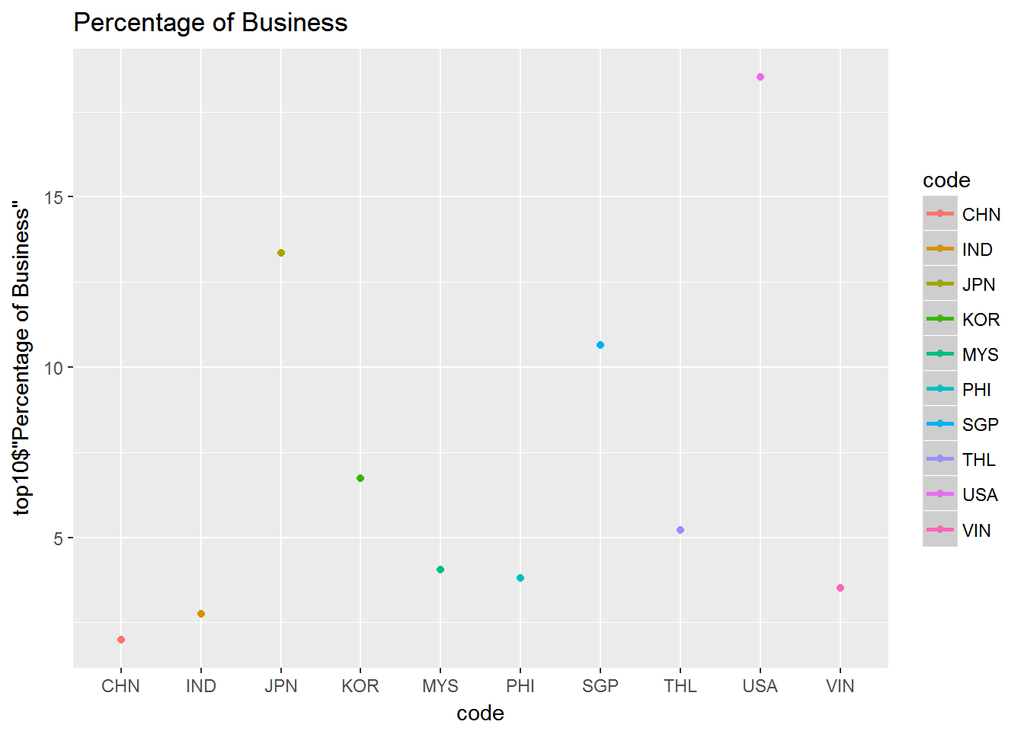

```r
library(dplyr)
library(ggplot2)
qplot(code, top10$"Percentage of Business",
      data=top10_purpose,color=code,
      main = "Percentage of Business",
      geom = c("point", "smooth"))
```

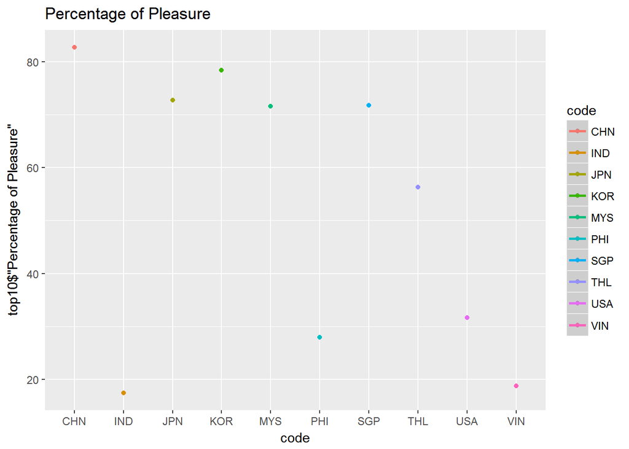

```r
qplot(code, top10$"Percentage of Pleasure", data=top10_purpose,color=code,
      main = "Percentage of Pleasure",
      geom = c("point", "smooth"))
```

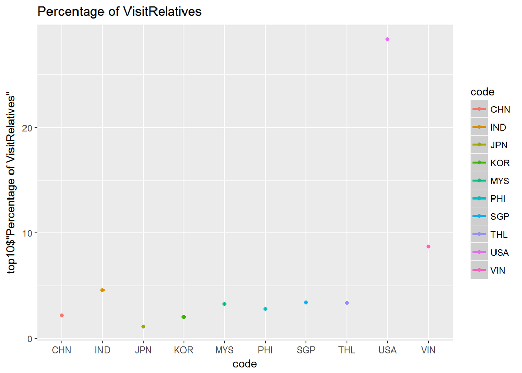

```r
qplot(code, top10$"Percentage of VisitRelatives", data=top10_purpose,color=code,
      main = "Percentage of VisitRelatives",
      geom = c("point", "smooth"))
```

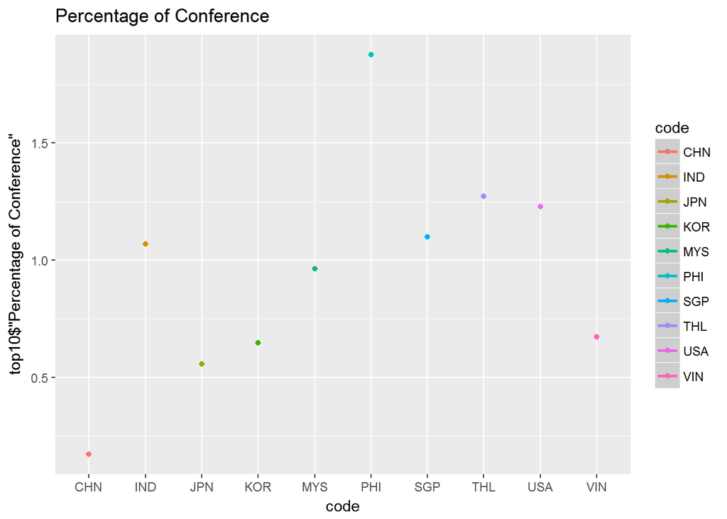

```r
qplot(code, top10$"Percentage of Conference", data=top10_purpose,color=code,
      main = "Percentage of Conference",
      geom = c("point", "smooth"))
```

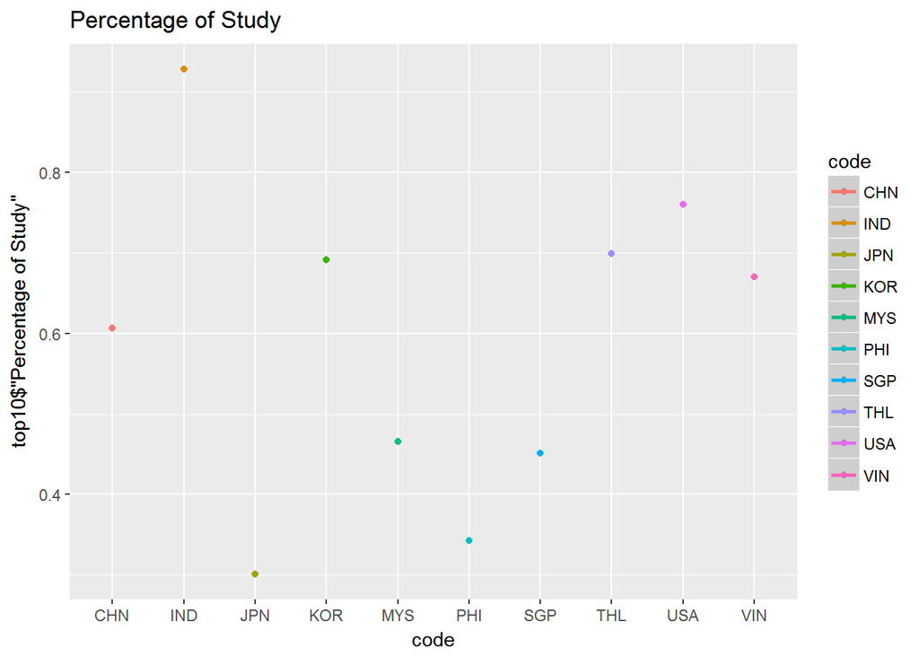

```r
qplot(code, top10$"Percentage of Study", data=top10_purpose,color=code,
      main = "Percentage of Study",
      geom = c("point", "smooth"))
```

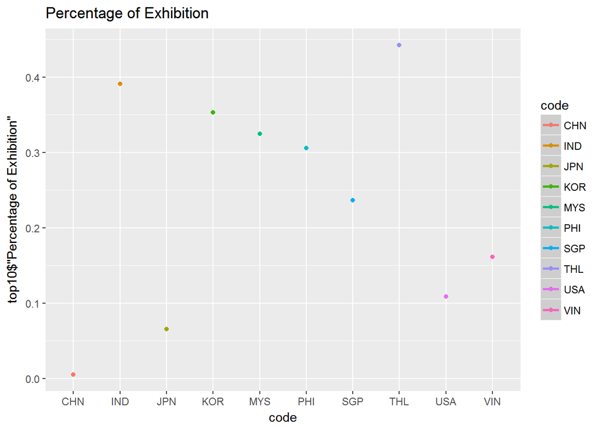

```r
qplot(code, top10$"Percentage of Exhibition", data=top10_purpose,color=code,
      main = "Percentage of Exhibition",
      geom = c("point", "smooth"))
```

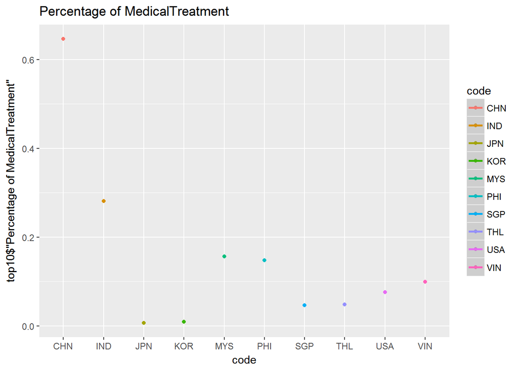

```r
qplot(code, top10$"Percentage of MedicalTreatment", data=top10_purpose,color=code,
      main = "Percentage of MedicalTreatment",
      geom = c("point", "smooth"))
```

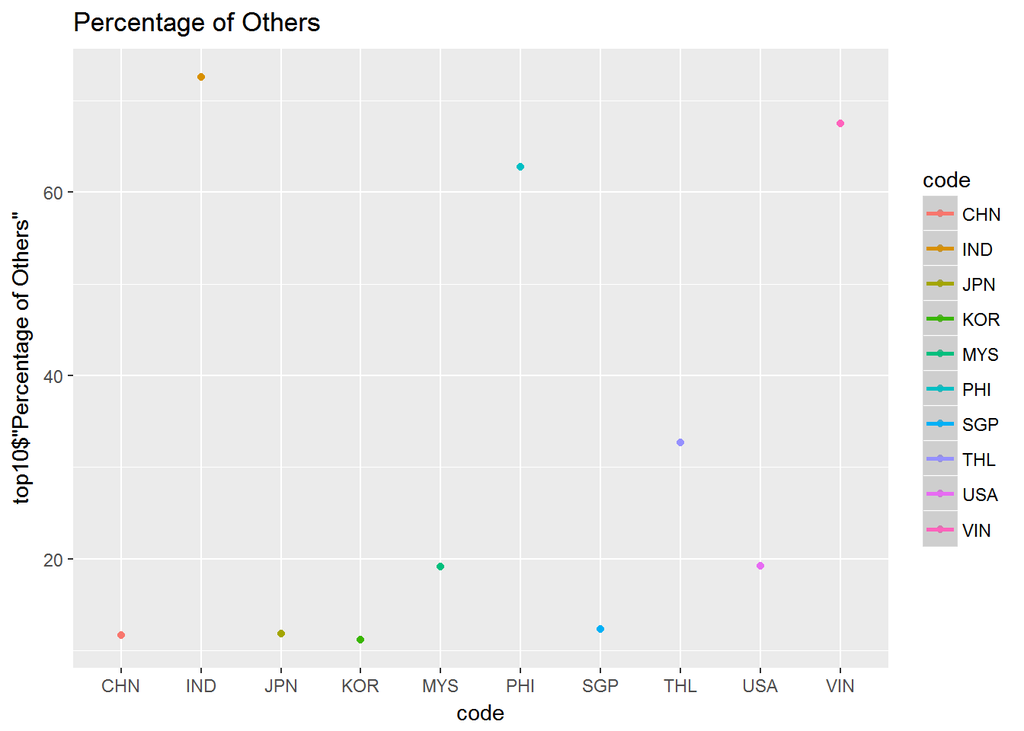

```r
qplot(code, top10$"Percentage of Others", data=top10_purpose,color=code,
      main = "Percentage of Others",
      geom = c("point", "smooth"))
```

```r
top10_purpose<-subset(top10,select =
                        c("code","Business","Pleasure","VisitRelatives","Conference","Study","Exhibition","MedicalTreatment","Others"))
head(top10_purpose,10)
```

```
## # A tibble: 10 x 9
##     code Business Pleasure VisitRelatives Conference Study Exhibition
##    <chr>    <dbl>    <dbl>          <dbl>      <dbl> <dbl>      <dbl>
##  1   CHN   102014  4242780         111667       8775 31104        269
##  2   JPN   253159  1379233          21403      10572  5707       1245
##  3   KOR    59578   693224          17791       5727  6112       3125
##  4   USA    97081   166044         148645       6434  3983        571
##  5   MYS    19269   339710          15475       4569  2211       1540
##  6   SGP    43378   292240          13931       4472  1839        964
##  7   VIN     6916    36839          17098       1321  1317        318
##  8   THL    10179   110116           6652       2490  1367        866
##  9   IND     5201    32868           8626       2019  1752        738
## 10   PHI     6551    48198           4843       3238   591        527
## # ... with 2 more variables: MedicalTreatment <dbl>, Others <dbl>
```

```r
library(reshape2)
top10.m <- melt(top10_purpose,id.vars = "code")
head(top10.m,10)
```

```
##    code variable  value
## 1   CHN Business 102014
## 2   JPN Business 253159
## 3   KOR Business  59578
## 4   USA Business  97081
## 5   MYS Business  19269
## 6   SGP Business  43378
## 7   VIN Business   6916
## 8   THL Business  10179
## 9   IND Business   5201
## 10  PHI Business   6551
```

```r
library(ggplot2)

library(dplyr)
top10.s<-top10_purpose %>%
    mutate_each(funs(scale), -code)
```

```
## `mutate_each()` is deprecated.
## Use `mutate_all()`, `mutate_at()` or `mutate_if()` instead.
## To map `funs` over a selection of variables, use `mutate_at()`
```

```r
head(top10.s,2)
```

```
## # A tibble: 2 x 9
##    code  Business  Pleasure VisitRelatives Conference      Study
##   <chr>     <dbl>     <dbl>          <dbl>      <dbl>      <dbl>
## 1   CHN 0.5403874 2.6963171       1.491095   1.277753 2.78449848
## 2   JPN 2.4999390 0.4957499      -0.302179   1.879888 0.01186695
## # ... with 3 more variables: Exhibition <dbl>, MedicalTreatment <dbl>,
## #   Others <dbl>
```

```r
top10.s.m <- melt(top10.s)
```

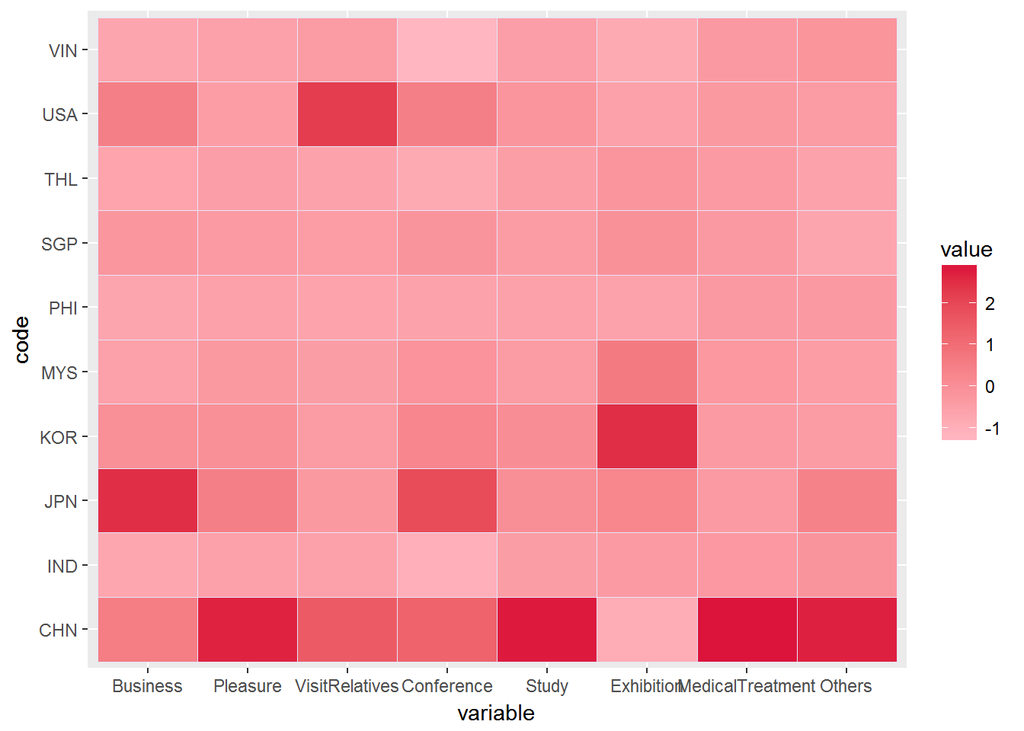

```r
ggplot(top10.s.m, aes(variable, code)) +
    geom_tile(aes(fill = value),
              colour = "#E6E6FA")+
    scale_fill_gradient(
        low = "#FFB6C1",high ="#DC143C")
```

```r
library(readr)
sex_2016<- read_csv("C:/Users/X550LD/Desktop/visitor arrivals by sex(2016) .csv")
View(sex_2016)
sex_2016$Residence<-
  iconv(sex_2016$Residence,
        from="big5", to = "UTF-8")
top10_male_female<-
  head(sex_2016[order(sex_2016$Total,decreasing = T),],10)
library(dplyr)
top10_male_female_code<-inner_join(countrycode,top10_male_female,by="Residence")
library(knitr)
knitr::kable(
  top10_male_female_code[1:10,])
```

[output not shown]

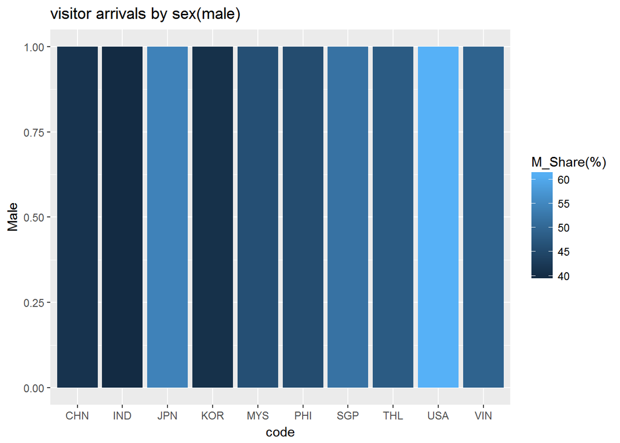

```r
library(ggplot2)
qplotmale<-
  qplot(x=code,
      data=top10_male_female_code,
      geom="bar",
      main = "visitor arrivals by sex(male) ",
      xlab="code",
      ylab = "Male",
      fill= `M_Share(%)`)
qplotmale
```

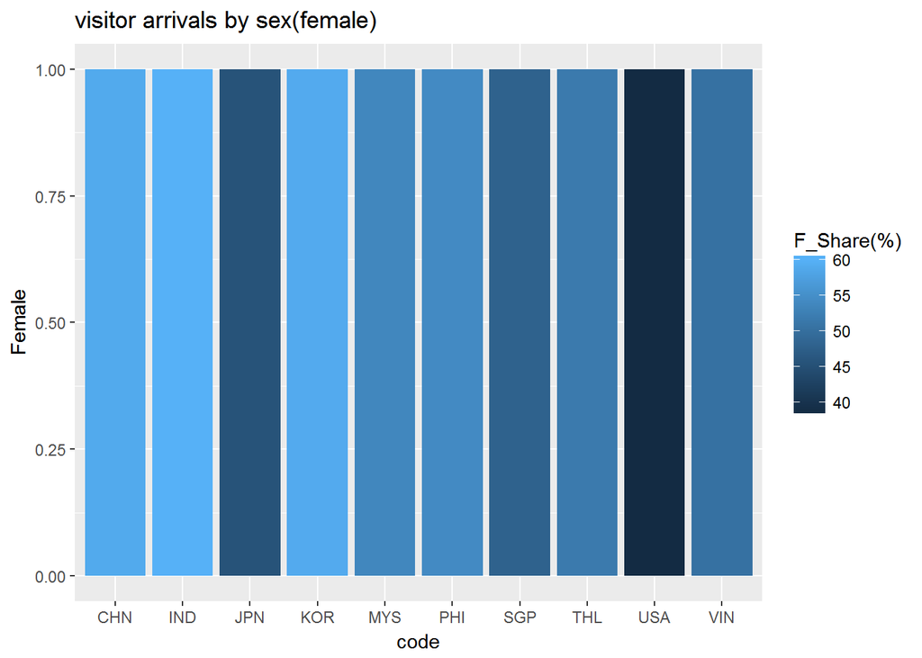

```r
library(ggplot2)
qplotfemale<-
  qplot(x=code,
      data=top10_male_female_code,
      geom="bar",
      main = "visitor arrivals by sex(female) ",
      xlab="code",
      ylab = "Female",
      fill=`F_Share(%)`)
qplotfemale
```

```r
library(readr)
reason <- read_csv("C:/Users/X550LD/Desktop/reason.csv")
View(reason)
library(data.table)
reason<-data.table(reason)
reason<-head(reason[order(reason$immigration_total,decreasing = T),],13)
reason<-subset(reason,select = c(abc,immigration_total))
library(knitr)
knitr::kable(
  reason[1:13,])
```

| abc | immigration_total |
| --- | --- |
| 觀光合計 | 2736053 |
| 一類觀光 | 1347433 |
| 個人旅遊 | 1308601 |
| 小三通(往來金、馬、澎) | 255795 |
| 其他 | 231523 |
| 專業交流合計 | 133461 |
| 短期專業交流 | 96539 |
| 商務交流合計 | 87729 |
| 三類觀光 | 80019 |
| 短期商務活動交流 | 78811 |
| 研修生 | 32648 |
| 健檢醫美 | 28112 |
| 履約活動 | 5252 |

```r
classification<-reason[grepl('合計',abc)]
library(knitr)
knitr::kable(
  classification[1:3,])
```

| abc | immigration_total |
| --- | --- |
| 觀光合計 | 2736053 |
| 專業交流合計 | 133461 |
| 商務交流合計 | 87729 |

```r
library(readr)
foreign_spouse <- read_csv("C:/Users/X550LD/Desktop/foreign_spouse.csv")
View(foreign_spouse)
foreign_spouse$'total105'<-as.numeric(foreign_spouse$'total105')
foreign_spouse<-head(foreign_spouse[order(foreign_spouse$'total105',decreasing = T),],5)
foreign_spouse<-subset(foreign_spouse,select = c('X1','total105','boy105','girl105'))
library(knitr)
knitr::kable(
  foreign_spouse[1:5,])
```

| X1 | total105 | boy105 | girl105 |
| --- | --- | --- | --- |
| 越南 | 1968 | 21 | 1947 |
| 印尼 | 337 | 19 | 318 |
| 泰國 | 277 | 2 | 275 |
| 菲律賓 | 258 | 16 | 242 |
| 馬來西亞 | 23 | 7 | 16 |

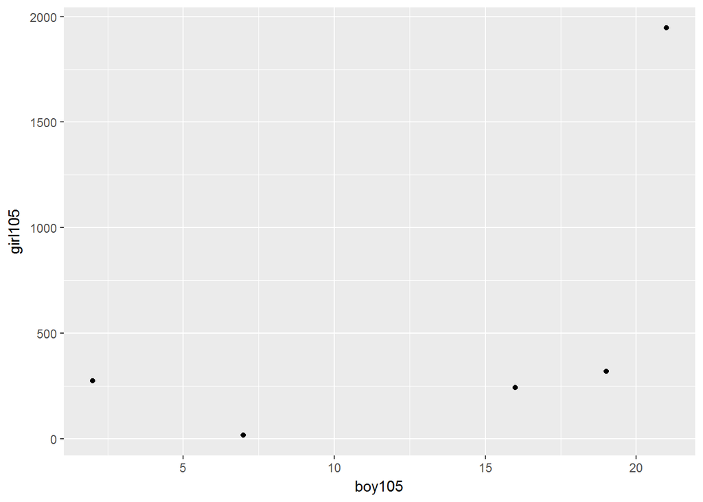

```r
library(ggplot2)
qplot(boy105,girl105,
      data = foreign_spouse)
```

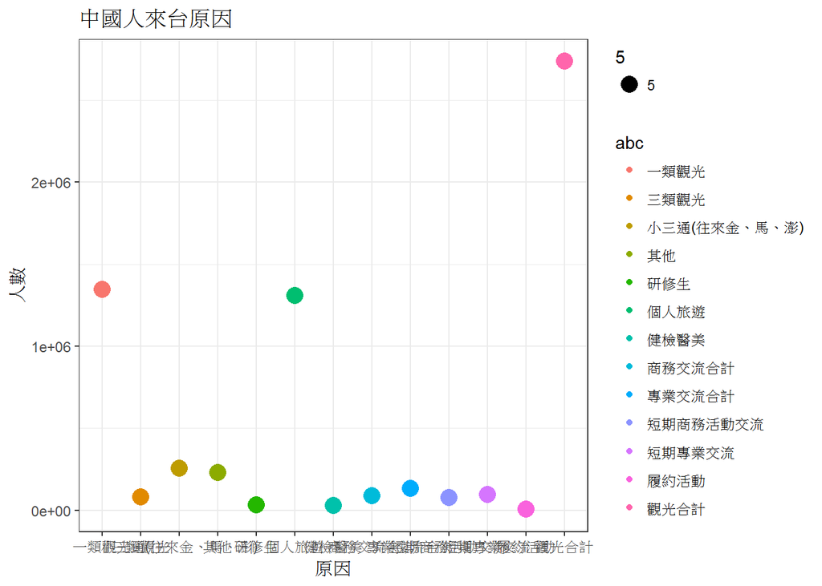

```r
library(ggplot2)
ggplot(data=reason) +
  geom_point(aes(x=abc,
                 y=immigration_total,
                 main="中國人來台原因",
                 color=abc,
                 size=5)) +
  labs(title="中國人來台原因",
       x="原因",
       y="人數") + theme_bw()
```

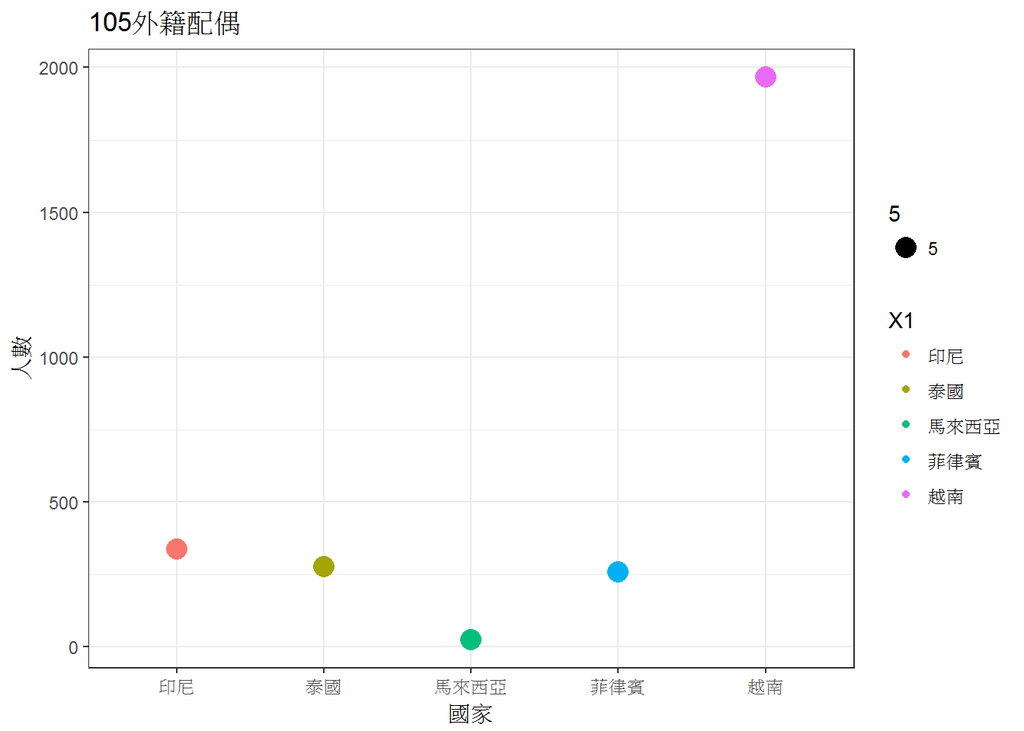

```r
ggplot(data=foreign_spouse) +
  geom_point(aes(x=X1,
                 y=total105,
                 main="105外籍配偶",
                 color=X1,
                 size=5)) +
  labs(title="105外籍配偶",
       x="國家",
       y="人數") + theme_bw()
```

## 期末專題分析規劃 期末專題時希望可以做出包含性別、年齡、以及對台灣外籍配偶分析，我國人吸引外籍來台分析等等。